# Workshop_3

2018-11-27

```r
check.packages_bioconductor <- function(pkg){
    new.pkg <- pkg[!(pkg %in%library()[]$result[,1])]
    source("https://bioconductor.org/biocLite.R")
    if (length(new.pkg))
        biocLite(new.pkg, dependencies = TRUE)
    sapply(pkg, library, character.only = TRUE)
}


# Check installation

check_installation_bio <- check.packages_bioconductor(packages_gene_ontology_bioconductor)
```

```r
# load packages
# Previous packages

packages_workspace <- c("rmarkdown","knitr", "citr")
packages_data <- c("tidyverse")
packages_networks <- c("igraph", "ggraph","tidygraph", "bipartite")

# Annotation packages

packages_gene_ontology_bioconductor <- c("AnnotationDbi","RBGL","GO.db","topGO","Rgraphviz","GSEABase")

packages_Lab <- c(packages_workspace,packages_data,packages_networks,packages_gene_ontology_bioconductor)

packages_Lab_load <- lapply(packages_Lab,library,character.only=TRUE)
```

# Gene Ontology

In large scale analyses genes and/or proteins are used as statistical objects. This approach can be enriched with existing knowledge for each gene-protein in order to obtain more insightful and biologicaly relevant results. This is a way of combining knowledge from single gene/protein genetic and biochemical research with the holistic approach of big data.

What are ontologies

Gene ontology content

Structure

```r
BP_children <- as.list(GOBPCHILDREN)
BP_children <- BP_children[!is.na(BP_children)]


BP_children_tidy <- unlist(BP_children)

BP_children_tidy_df <- data.frame(GO.type.relation=names(BP_children_tidy),relation_GO=BP_children_tidy) %>% mutate(type.relation=gsub("(.*)\\.(.*)","\\2",GO.type.relation), GO.term=gsub("(.*)\\.(.*)","\\1",GO.type.relation)) # %>% mutate(Term=sapply(X = GO.term, FUN = Term))
```

Relationships

- is a
- part of
- has part
- regulates
- positevely regulates

As a tool

## Gene ontology annotation in r

Bioconductor has packages in R that do Gene Ontology annotation in genes of many organisms with different types of database IDs. For detailed tutorials look (Sinha 2014).

```r
# data from Biogrid
Escherichia_coli_biogrid <- read.delim(file = "Data/BIOGRID-ORGANISM-Escherichia_coli_K12_MG1655-3.5.166.mitab.txt",sep = "\t",header = T) %>% mutate(InteractorA_entrez=gsub("(.*):(.*)","\\2",X.ID.Interactor.A), InteractorB_entrez=gsub("(.*):(.*)","\\2",ID.Interactor.B))

Escherichia_coli_biogrid_proteins <- as.character(unique(c(Escherichia_coli_biogrid$InteractorA_entrez,Escherichia_coli_biogrid$InteractorB_entrez))) # gene universe

Escherichia_coli_biogrid_physical_association <- Escherichia_coli_biogrid %>% filter(Interaction.Types %in% c("psi-mi:MI:0407(direct interaction)","psi-mi:MI:0915(physical association)"))

Escherichia_coli_biogrid_physical_association_proteins <- as.character(unique(c(Escherichia_coli_biogrid_physical_association$InteractorA_entrez,Escherichia_coli_biogrid_physical_association$InteractorB_entrez))) # genes of interest
```

## Identifiers with AnnotationDPi

```r
if (!requireNamespace("BiocManager", quietly = TRUE))
    install.packages("BiocManager")
BiocManager::install("org.EcK12.eg.db", version = "3.8")
```

```r
library(org.EcK12.eg.db)

my_map <- org.EcK12.eg.db

columns(org.EcK12.eg.db)
```

```
##  [1] "ACCNUM"      "ALIAS"       "ENTREZID"    "ENZYME"      "EVIDENCE"
##  [6] "EVIDENCEALL" "GENENAME"    "GO"          "GOALL"       "ONTOLOGY"
## [11] "ONTOLOGYALL" "PATH"        "PMID"        "REFSEQ"      "SYMBOL"
```

```r
keys_entrez <- keys(org.EcK12.eg.db,keytype = "ENTREZID")

Escherichia_coli_ENTREZID_symbol <- AnnotationDbi::select(org.EcK12.eg.db, keys=keys_entrez, columns = c("ENTREZID","SYMBOL")) %>% mutate(PPI= ENTREZID %in% Escherichia_coli_biogrid_physical_association_proteins)
```

## Singular enrichment analysis

In order to examine which gene ontology terms are overrepresented in the genes of our network we have to do a statistic test. Most commonly used tests is the Fisher’s exact test, the chi square test and the binomial test. We will use the Fisher’ s exact test for the Biological Process component of Gene Ontology.

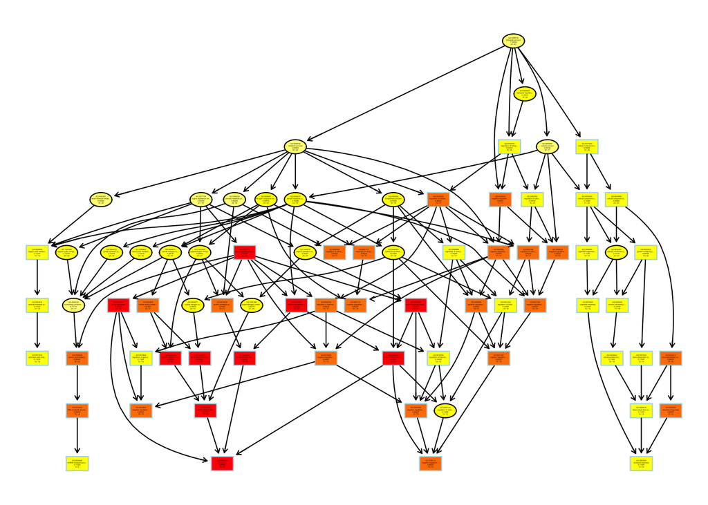

```r
####################################### Plot GO graph #########################################

showSigOfNodes <- showSigOfNodes(sampleGOdata, score(resultFisher), firstSigNodes = 53, useInfo = 'all')
```

```r
# it induces the GO graph with the quered IDs.
showSigOfNodes
```

```
## $dag
## A graphNEL graph with directed edges
## Number of Nodes = 75
## Number of Edges = 151
##
## $complete.dag
## [1] "A graph with 75 nodes."
```

```r
printGraph(sampleGOdata, resultFisher, firstSigNodes = 10, useInfo = 'all',fn.prefix = "Gene Ontology enriched terms", pdfSW = TRUE)
```

```
## Gene Ontology enriched terms_classic_10_all  --- no of nodes:  26
```

```
## IGRAPH d93963a DNW- 75 151 --
## + attr: name (v/c), weight (e/n)
```

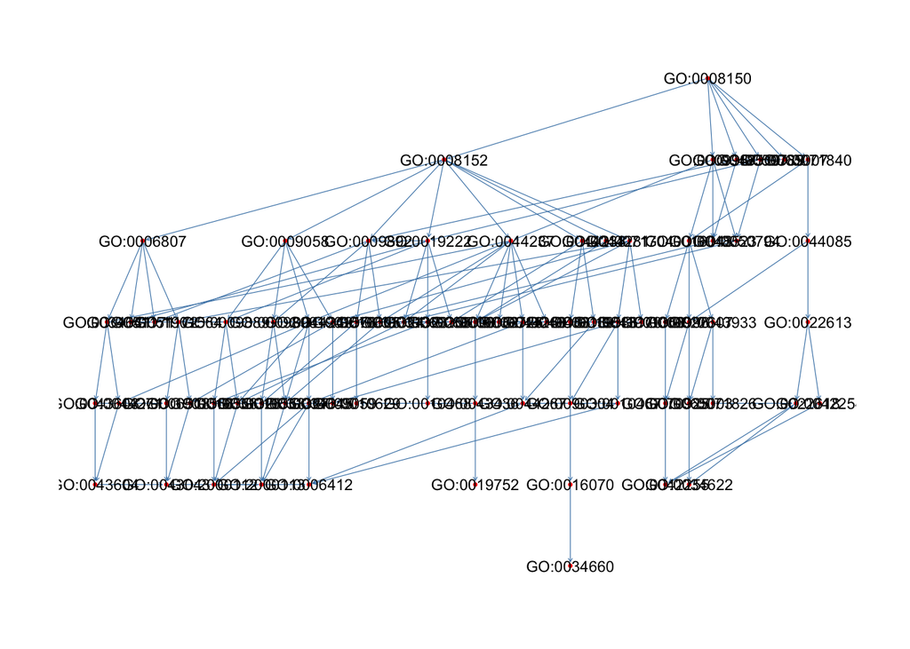

```r
showSigOfNodes_igraph <- graph_from_graphnel(showSigOfNodes$dag, name = TRUE, weight = TRUE,
  unlist.attrs = TRUE)

summary(showSigOfNodes_igraph)
```

All these test share the same assumption for the null hypothesis, that the probabilities for the selection of each gene are equal (Rivals et al. 2007). But it turns out that thay are not because the structure of gene ontology bipartite network of genes and gene terms has a heavy tail distribution and hence these tests are biased to high degree terms (Glass and Girvan 2014).

[Nice explanation to the biases of gene ontology](http://khughitt.github.io/slidify-annotation_enrichment_analysis/#1)

# Kegg pathway annotation

```r
library(KEGGgraph)
library(KEGG.db)
library(org.Dm.eg.db)
library(KEGGREST)


proteins_cluster <- intresting_genes_Essential
myEID <- unlist(mget(proteins_cluster, org.Dm.egFLYBASE2EG, ifnotfound=NA))
myEID <- as.character(myEID)

kegg <- as.data.frame(unlist(mget(as.character(myEID), org.Dm.egPATH,
       ifnotfound=list(NA))),row.names = NULL) %>% tibble::rownames_to_column(.,var="Var1")
colnames(kegg) <- c("entrez_id", "kegg_pathway_id")

kegg_summary <- kegg %>% group_by(kegg_pathway_id) %>% summarize(proteins=n()) %>% ungroup()

kegg_summary[1,3] <- keggGet("dme00190")[[1]]$NAME
kegg_summary[2,3] <- keggGet("dme01100")[[1]]$NAME
kegg_summary[3,3] <- keggGet("dme03010")[[1]]$NAME
kegg_summary[4,3] <- keggGet("dme03050")[[1]]$NAME

colnames(kegg_summary) <- c("kegg pathway id", "proteins", "kegg pathway name")

write.table(x = kegg_summary, file = "../Thesis_Essentiality_Drosophila_Signed_Network/Tables/Essential_cluster_kegg_summary.csv", sep = ",", col.names = TRUE,row.names = FALSE)

library(pathview)

pv.out_1 <- pathview(gene.data = kegg$entrez_id, pathway.id = as.character(kegg_summary$kegg_pathway_id[1]), species = "dme", out.suffix = "dros_essential_cluster", kegg.native = F)

pv.out_2 <- pathview(gene.data = kegg$entrez_id, pathway.id = as.character(kegg_summary$kegg_pathway_id[2]), species = "dme", out.suffix = "dros_essential_cluster", kegg.native = F)

pv.out_3 <- pathview(gene.data = kegg$entrez_id, pathway.id = as.character(kegg_summary$kegg_pathway_id[3]), species = "dme", out.suffix = "dros_essential_cluster", kegg.native = F)

pv.out_4 <- pathview(gene.data = kegg$entrez_id, pathway.id = as.character(kegg_summary$kegg_pathway_id[4]), species = "dme", out.suffix = "dros_essential_cluster", kegg.native = F)

pv.out_4b <- pathview(gene.data = kegg$entrez_id, pathway.id = as.character(kegg_summary$kegg_pathway_id[4]), species = "dme", out.suffix = "dros_essential_cluster", kegg.native = F,same.layer = F)



## 1

retrieveKGML("dme00190", organism="dme",destfile = "../Thesis_Essentiality_Drosophila_Signed_Network/Data/dme00190kegg.xml", method="wget", quiet=TRUE)

dme00190pathway <- parseKGML("../Thesis_Essentiality_Drosophila_Signed_Network/Data/dme00190kegg.xml")

dme00190pathway2 <- KEGGpathway2Graph(dme00190pathway, expandGenes=TRUE,genesOnly = T)


## 2

# retrieveKGML("dme01100", organism="dme",destfile = "../Thesis_Essentiality_Drosophila_Signed_Network/Data/dme01100kegg.xml", method="wget", quiet=TRUE)
#
# dme01100pathway <- parseKGML("../Thesis_Essentiality_Drosophila_Signed_Network/Data/dme01100kegg.xml")
#
# dme01100pathway2 <- KEGGpathway2Graph(dme01100pathway, expandGenes=TRUE,genesOnly = T)
# dme01100pathway2

## 3

retrieveKGML("dme03010", organism="dme",destfile = "../Thesis_Essentiality_Drosophila_Signed_Network/Data/dme03010kegg.xml", method="wget", quiet=TRUE)

dme03010pathway <- parseKGML("../Thesis_Essentiality_Drosophila_Signed_Network/Data/dme03010kegg.xml")

dme03010pathway2 <- KEGGpathway2Graph(dme03010pathway, expandGenes=TRUE,genesOnly = T)


## 4
retrieveKGML("dme03050", organism="dme",destfile = "../Thesis_Essentiality_Drosophila_Signed_Network/Data/dme03050kegg.xml", method="wget", quiet=TRUE)

dme03050pathway <- parseKGML("../Thesis_Essentiality_Drosophila_Signed_Network/Data/dme03050kegg.xml")

dme03050pathway2 <- KEGGpathway2Graph(dme03050pathway, expandGenes=TRUE,genesOnly = F)


# png <- keggGet(c( "dme01100"), "image")
# t <- tempfile()
# library(png)
# writePNG(png, t)
# if (interactive()) browseURL(t)
#
# tmp <- tempfile()
# #pName <- "p53 signaling pathway"
# pId <- as.character(kegg_summary$kegg_pathway_id[2])
# retrieveKGML(pId, organism="dme", destfile=tmp, method="wget", quiet=TRUE)
```

# References

Glass, Kimberly, and Michelle Girvan. 2014. “Annotation enrichment analysis: an alternative method for evaluating the functional properties of gene sets.” *Sci. Rep.* 4: 4191. doi:10.1038/srep04191.

Rivals, Isabelle, Léon Personnaz, Lieng Taing, and Marie Claude Potier. 2007. “Enrichment or depletion of a GO category within a class of genes: Which test?” *Bioinformatics* 23 (4): 401–7. doi:10.1093/bioinformatics/btl633.

Sinha, Paurush Praveen. 2014. *Bioinformatics with R Cookbook*. doi:http://www.crcpress.com/shopping_cart/products/product_detail.asp?sku=C6367.